# Task 6.5: Clustering – CWUR University Rankings

## Hypothesis

Universities can be grouped into distinct clusters based on their performance metrics (such as alumni employment, publications, faculty quality, and overall score). These clusters may reveal patterns of elite, mid-tier, and emerging universities.

## 1. Import Libraries

```python
import pandas as pd
import numpy as np
import matplotlib.pyplot as plt
import seaborn as sns
from sklearn.preprocessing import StandardScaler
from sklearn.decomposition import PCA
from sklearn.cluster import KMeans
```

```python
cwur_df = pd.read_csv("cwur_clean.csv")
# Inspect
cwur_df.head()
```

|  | world_rank | institution | country | national_rank | quality_of_education | alumni_employment | quality_of_faculty | publications | influence | citations | broad_impact | patents | score | year |
| --- | --- | --- | --- | --- | --- | --- | --- | --- | --- | --- | --- | --- | --- | --- |
| 0 | 1 | Harvard University | USA | 1 | 7 | 9 | 1 | 1 | 1 | 1 | NaN | 5 | 100.00 | 2012 |
| 1 | 2 | Massachusetts Institute of Technology | USA | 2 | 9 | 17 | 3 | 12 | 4 | 4 | NaN | 1 | 91.67 | 2012 |
| 2 | 3 | Stanford University | USA | 3 | 17 | 11 | 5 | 4 | 2 | 2 | NaN | 15 | 89.50 | 2012 |
| 3 | 4 | University of Cambridge | United Kingdom | 1 | 10 | 24 | 4 | 16 | 16 | 11 | NaN | 50 | 86.17 | 2012 |
| 4 | 5 | California Institute of Technology | USA | 4 | 2 | 29 | 7 | 37 | 22 | 22 | NaN | 18 | 85.21 | 2012 |

## 2. Data Cleaning & Feature Selection

I selected relevant numeric features, handled missing values, and applied standard scaling to ensure comparability across variables.

```python
# Select Features and Scale
features = ["score", "publications", "citations", "patents"]
X = cwur_df[features].dropna()

scaler = StandardScaler()
X_scaled = scaler.fit_transform(X)
```

```python
# Select only numeric variables relevant for clustering
X = cwur_df[["quality_of_education", "alumni_employment", "quality_of_faculty",
             "publications", "influence", "citations", "broad_impact", "patents", "score"]]

# Drop rows with missing values
X = X.dropna()

# Standardize features
scaler = StandardScaler()
X_scaled = scaler.fit_transform(X)

print(X.shape, X_scaled.shape)
```

```
(2000, 9) (2000, 9)
```

## Data Preparation

I will select only **numerical columns** for clustering.  
Categorical variables such as university name, country, and year will be dropped.  
I also standardize the data using `StandardScaler` to ensure all features contribute equally to clustering.

## 3. Select numerical features

```python
numeric_cols = cwur_df.select_dtypes(include=[np.number]).columns
X = cwur_df[numeric_cols]

# Standardize
scaler = StandardScaler()
X_scaled = scaler.fit_transform(X)

X_scaled[:5]
```

```
array([[-1.50727729, -0.7593052 , -2.19921423, -1.86421115, -2.77792608,
        -1.51110231, -1.51287139, -1.56037531,         nan, -1.56368315,
         6.72784112, -3.04240493],
       [-1.50399053, -0.73997372, -2.18280833, -1.8213701 , -2.74669381,
        -1.47488132, -1.50297898, -1.54902485,         nan, -1.57828519,
         5.65425503, -3.04240493],
       [-1.50070377, -0.72064225, -2.11718475, -1.85350088, -2.71546153,
        -1.50122386, -1.50957392, -1.55659182,         nan, -1.52717804,
         5.37458134, -3.04240493],
       [-1.49741701, -0.7593052 , -2.17460539, -1.78388418, -2.73107767,
        -1.46171005, -1.46340935, -1.52254044,         nan, -1.39941015,
         4.94540467, -3.04240493],
       [-1.49413025, -0.70131077, -2.24022897, -1.75710853, -2.68422926,
        -1.39256089, -1.44362454, -1.48092209,         nan, -1.5162265 ,
         4.82167806, -3.04240493]])
```

# 4. Elbow Method

To determine the optimal number of clusters (k), I use the elbow method.  
I plot the inertia (within-cluster sum of squares) for different values of k.

### Handle Missing Values

```python
# Drop rows with NaN in numeric columns
X = X.dropna()

# Scale again after dropping NaN
X_scaled = scaler.fit_transform(X)

print("Shape after dropping NaN:", X.shape)
```

```
Shape after dropping NaN: (2000, 12)
```

# Elbow Method to Determine Optimal k

The elbow method was used to determine the optimal number of clusters. The "elbow" was observed at k=3, suggesting three meaningful clusters in the dataset

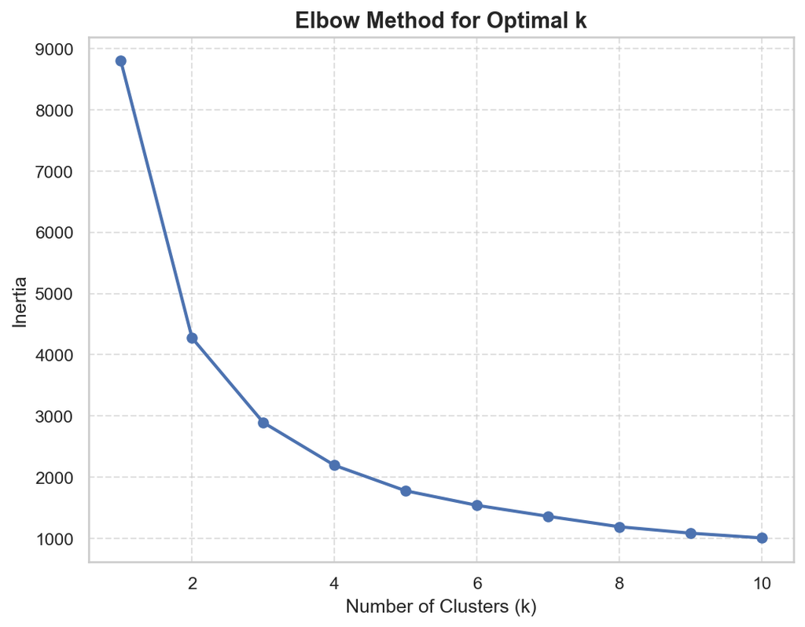

```python
inertia = []
K = range(1, 11)
for k in K:
    kmeans = KMeans(n_clusters=k, random_state=42, n_init=10)
    kmeans.fit(X_scaled)
    inertia.append(kmeans.inertia_)

plt.figure(figsize=(8,6), dpi=150)
plt.plot(K, inertia, "o-", linewidth=2)
plt.xlabel("Number of Clusters (k)", fontsize=12)
plt.ylabel("Inertia", fontsize=12)
plt.title("Elbow Method for Optimal k", fontsize=14, weight="bold")
plt.grid(True, linestyle="--", alpha=0.6)
plt.show()
```

**Insight:** The elbow point indicates the optimal number of clusters. Typically, a bend around k = 3 or k = 4 suggests a reasonable choice.

### Why k=3?

Based on the elbow plot, the curve begins to flatten at **k=3**, which indicates diminishing returns when adding more clusters. Choosing 3 clusters provides a good balance between simplicity and capturing meaningful structure in the data.

```python
# 3. Fit KMeans ( k=3 as example)
kmeans = KMeans(n_clusters=3, random_state=42, n_init=10)
cwur_df.loc[X.index, "cluster"] = kmeans.fit_predict(X_scaled)
```

### Interpreting the Elbow Method

The elbow method plot shows that inertia decreases rapidly at first and then starts to level off.  
The "elbow" point appears around **K=3**, suggesting that three clusters provide the best balance between simplicity and performance.  
This value of K was therefore chosen for the KMeans clustering analysis.

## KMeans Clustering

Based on the elbow plot, ı select an appropriate number of clusters (k).  
Here I choose **k = 3** (this can be adjusted if the elbow suggests another value).

```python
import matplotlib.pyplot as plt
```

```python
from sklearn.preprocessing import StandardScaler

# --- Select numeric columns ---
X = cwur_df[[
    "quality_of_education", "alumni_employment", "quality_of_faculty",
    "publications", "influence", "citations", "broad_impact", "patents", "score"
]]

# --- Drop rows with missing values ---
X = X.dropna()

# --- Standardize features ---
scaler = StandardScaler()
X_scaled = scaler.fit_transform(X)
```

```python
# --- Run KMeans ---
kmeans = KMeans(n_clusters=3, random_state=42, n_init=10)
labels = kmeans.fit_predict(X_scaled)

# --- Create a DataFrame with clustering results ---
cwur_clustered = cwur_df.loc[X.index].copy()
cwur_clustered["cluster"] = labels

cwur_clustered[["institution", "country", "score", "cluster"]].head()
```

|  | institution | country | score | cluster |
| --- | --- | --- | --- | --- |
| 200 | Harvard University | USA | 100.00 | 2 |
| 201 | Stanford University | USA | 99.09 | 2 |
| 202 | Massachusetts Institute of Technology | USA | 98.69 | 2 |
| 203 | University of Cambridge | United Kingdom | 97.64 | 2 |
| 204 | University of Oxford | United Kingdom | 97.51 | 2 |

### Cluster Descriptive Statistics

# 5. Visualizations

## Scatterplot of Clusters: Score vs. Citations

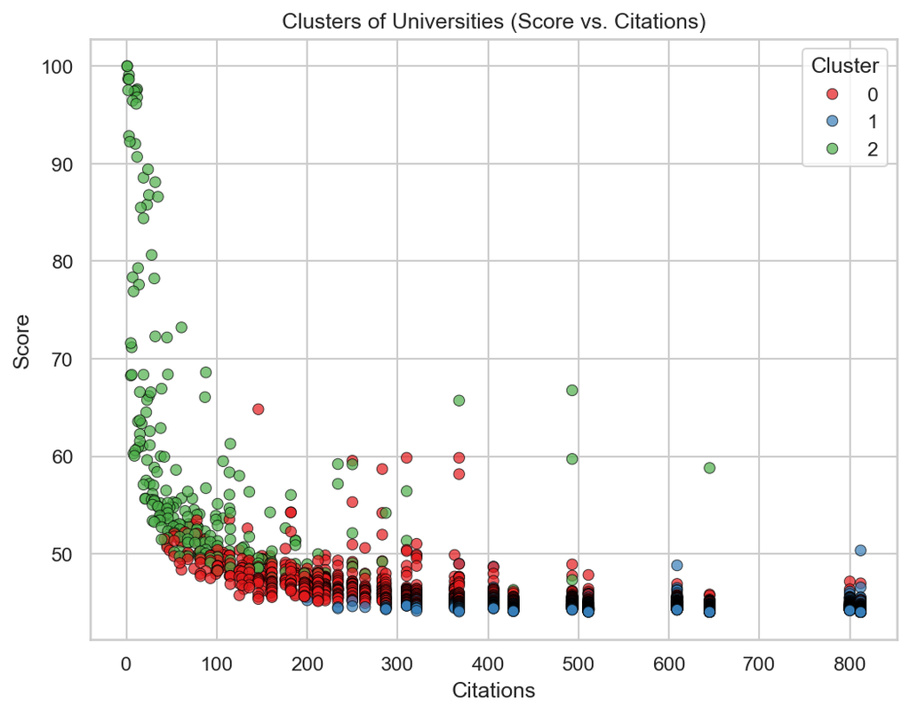

```python
plt.figure(figsize=(8,6), dpi=(150))
sns.scatterplot(
    data=cwur_clustered,
    x="citations",
    y="score",
    hue="cluster",
    palette="Set1",
    alpha=0.7,
    edgecolor="black",
)
plt.title("Clusters of Universities (Score vs. Citations)")
plt.xlabel("Citations")
plt.ylabel("Score")
plt.legend(title="Cluster")
plt.show()
```

### Insights: Score vs. Citations

This plot shows the relationship between **score** and **citations** for universities.

Elite universities (Cluster 2) stand out clearly, showing strong performance across both overall scores and research impact.

### Cluster Interpretation and Descriptive Statistics

The scatterplot (Score vs. Citations) also supports this distinction, where universities naturally form three tiers: elite, mid-range, and developing.

This analysis confirms that clustering provides a meaningful segmentation of universities worldwide.

## Scatterplot of Clusters: Alumni Employment vs. Score

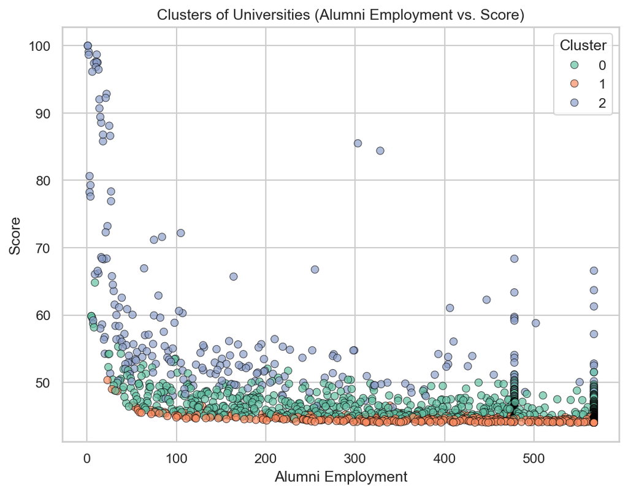

```python
plt.figure(figsize=(8,6), dpi=(150))
sns.scatterplot(
    data=cwur_clustered,
    x="alumni_employment",
    y="score",
    hue="cluster",
    palette="Set2",
    edgecolor="black",
    alpha=0.7
)
plt.title("Clusters of Universities (Alumni Employment vs. Score)")
plt.xlabel("Alumni Employment")
plt.ylabel("Score")
plt.legend(title="Cluster")
plt.show()
```

### Insights: Alumni Employment vs. Score

This visualization explores the relationship between **alumni employment** and overall **score**.

This suggests that alumni employment alone is not the key driver of university ranking scores; research output and publications also play a significant role.

## Scatterplot of Clusters: Faculty Quality vs. Citations

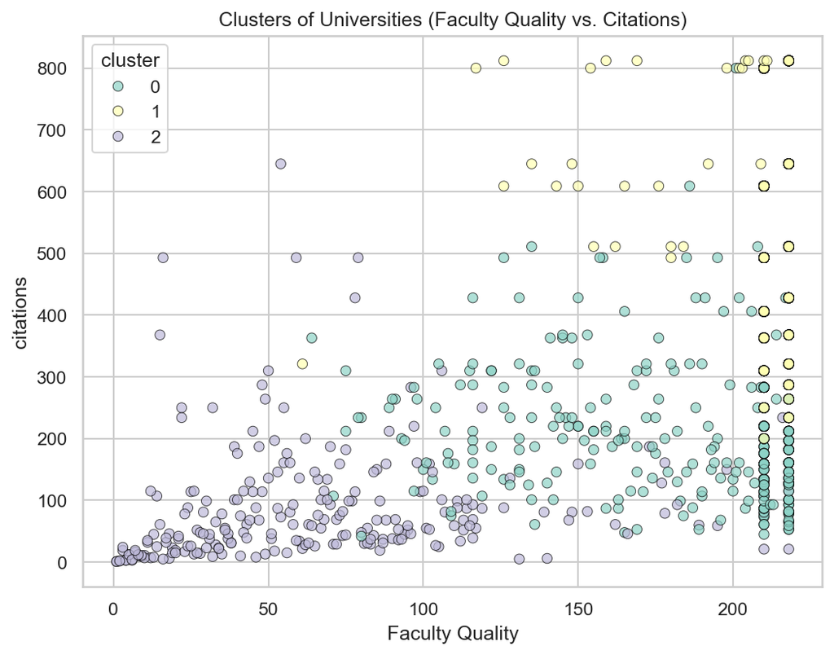

```python
plt.figure(figsize=(8,6), dpi=(150))
sns.scatterplot(
    data=cwur_clustered,
    x="quality_of_faculty",
    y="citations",
    hue="cluster",
    palette="Set3",
    alpha=0.7,
    edgecolor="black"
)
plt.title("Clusters of Universities (Faculty Quality vs. Citations)")
plt.xlabel("Faculty Quality")
```

### Insights: Faculty Quality vs. Citations

This plot illustrates the relationship between **faculty quality** and **citations**, broken down by clusters.

# 6. Run KMeans

```python
kmeans = KMeans(n_clusters=3, random_state=42, n_init=10)
```

```python
# Fit on scaled X
labels = kmeans.fit_predict(X_scaled)
```

```python
# Create a new DataFrame that only includes rows used in clustering
cwur_clustered = cwur_df.loc[X.index].copy()
cwur_clustered["cluster"] = labels
```

```python
print(cwur_df.columns.tolist())
```

```
['world_rank', 'institution', 'country', 'national_rank', 'quality_of_education', 'alumni_employment', 'quality_of_faculty', 'publications', 'influence', 'citations', 'broad_impact', 'patents', 'score', 'year']
```

```python
cwur_clustered[["institution", "country", "score", "cluster"]].head()
```

|  | institution | country | score | cluster |
| --- | --- | --- | --- | --- |
| 200 | Harvard University | USA | 100.00 | 2 |
| 201 | Stanford University | USA | 99.09 | 2 |
| 202 | Massachusetts Institute of Technology | USA | 98.69 | 2 |
| 203 | University of Cambridge | United Kingdom | 97.64 | 2 |
| 204 | University of Oxford | United Kingdom | 97.51 | 2 |

```python
cwur_clustered.groupby("cluster").mean(numeric_only=True)
```

| cluster | world_rank | national_rank | quality_of_education | alumni_employment | quality_of_faculty | publications | influence | citations | broad_impact | patents | score | year |
| --- | --- | --- | --- | --- | --- | --- | --- | --- | --- | --- | --- | --- |
| 0 | 312.509383 | 37.067024 | 295.927614 | 348.344504 | 199.816354 | 308.533512 | 321.924933 | 304.855228 | 304.579088 | 374.623324 | 46.716515 | 2014.485255 |
| 1 | 736.881256 | 52.067713 | 343.096173 | 457.552502 | 212.855741 | 734.352306 | 727.689892 | 638.328754 | 731.921492 | 612.447498 | 44.518999 | 2014.513248 |
| 2 | 72.280851 | 18.412766 | 92.025532 | 189.004255 | 69.327660 | 95.144681 | 79.855319 | 88.527660 | 86.617021 | 157.825532 | 59.233532 | 2014.489362 |

### University Clusters (PCA 2D Projection)

```python
from sklearn.preprocessing import StandardScaler

# Select relevant numerical columns
features = ["score", "publications", "citations", "patents"]
X = cwur_df[features].dropna()

# Scale features
scaler = StandardScaler()
X_scaled = scaler.fit_transform(X)
```

```python
from sklearn.decomposition import PCA

pca = PCA(n_components=2)
pca_result = pca.fit_transform(X_scaled)

# Create columns in dataframe (only for rows without NaN)
cwur_df.loc[X.index, "pca1"] = pca_result[:, 0]
cwur_df.loc[X.index, "pca2"] = pca_result[:, 1]
```

[figure not shown]

```python
# --- 4. PCA for Visualization ---
pca = PCA(n_components=2)
pca_result = pca.fit_transform(X_scaled)

cwur_df.loc[X.index, "pca1"] = pca_result[:, 0]
cwur_df.loc[X.index, "pca2"] = pca_result[:, 1]

plt.figure(figsize=(12,8), dpi=150)
sns.set(style="whitegrid")

sns.scatterplot(
    x="pca1", y="pca2",
    hue="cluster",
    palette=sns.color_palette("Spectral", n_colors=3),
    data=cwur_df,
    s=70, edgecolor="black", alpha=0.7
)
plt.title("Clusters of Universities (PCA Projection)", fontsize=16, weight="bold")
plt.xlabel("Principal Component 1", fontsize=13)
plt.ylabel("Principal Component 2", fontsize=13)
plt.legend(title="Cluster", fontsize=12)
plt.show()
```

### Insights: PCA Projection (Clusters of Universities)

This visualization shows how universities are grouped in a 2D space reduced by PCA from the original multi-dimensional dataset.

This separation confirms that K-means clustering effectively distinguishes universities based on their performance levels.

```python
cluster_stats = cwur_clustered.groupby("cluster")[["score", "publications", "citations", "patents"]].mean()
cluster_stats
```

| cluster | score | publications | citations | patents |
| --- | --- | --- | --- | --- |
| 0 | 46.716515 | 308.533512 | 304.855228 | 374.623324 |
| 1 | 44.518999 | 734.352306 | 638.328754 | 612.447498 |
| 2 | 59.233532 | 95.144681 | 88.527660 | 157.825532 |

```python
# Drop rows with NaN in clustering features
features = ["score", "publications", "citations", "patents"]
cwur_clustering = cwur_df.dropna(subset=features).reset_index(drop=True)

# Scale
from sklearn.preprocessing import StandardScaler
scaler = StandardScaler()
X_scaled = scaler.fit_transform(cwur_clustering[features])
```

```python
# Fit KMeans (choose k=3 as example)
kmeans = KMeans(n_clusters=3, random_state=42, n_init=10)
cwur_df.loc[X.index, "cluster"] = kmeans.fit_predict(X_scaled)
```

```python
# Select only relevant features
features = ["score", "publications", "citations", "patents"]

# Drop rows with NaN only in these features
cwur_clustering = cwur_df.dropna(subset=features).reset_index(drop=True)

# Scale the features
from sklearn.preprocessing import StandardScaler
scaler = StandardScaler()
X_scaled = scaler.fit_transform(cwur_clustering[features])

print(cwur_clustering.shape, X_scaled.shape)
```

```
(2200, 17) (2200, 4)
```

```python
from sklearn.cluster import KMeans

# Run KMeans on cleaned data
kmeans = KMeans(n_clusters=3, random_state=42, n_init=10)
cwur_clustering["cluster"] = kmeans.fit_predict(X_scaled)

# Preview with cluster labels
cwur_clustering[["institution", "country", "score", "cluster"]].head()
```

|  | institution | country | score | cluster |
| --- | --- | --- | --- | --- |
| 0 | Harvard University | USA | 100.00 | 2 |
| 1 | Massachusetts Institute of Technology | USA | 91.67 | 2 |
| 2 | Stanford University | USA | 89.50 | 2 |
| 3 | University of Cambridge | United Kingdom | 86.17 | 2 |
| 4 | California Institute of Technology | USA | 85.21 | 2 |

## Cluster Descriptive Statistics

```python
# Average score by cluster
cluster_stats = cwur_clustered.groupby("cluster")[["score"]].mean()
print("Average score by cluster:")
display(cluster_stats)

# Count of universities by cluster
cluster_counts = cwur_clustered["cluster"].value_counts()
print("\nNumber of universities in each cluster:")
display(cluster_counts)
```

```
Average score by cluster:
```

| cluster | score |
| --- | --- |
| 0 | 46.716515 |
| 1 | 44.518999 |
| 2 | 59.233532 |

```
Number of universities in each cluster:
```

```
cluster
1    1019
0     746
2     235
Name: count, dtype: int64
```

```python
# Cluster-level Descriptive Statistics
cluster_summary = (
    cwur_df.groupby("cluster")[["score", "publications", "citations", "patents"]]
    .mean()
    .round(2)
)
print("Cluster-Level Descriptive Statistics:\n")
display(cluster_summary)
```

```
Cluster-Level Descriptive Statistics:
```

| cluster | score | publications | citations | patents |
| --- | --- | --- | --- | --- |
| 0.0 | 48.74 | 197.47 | 193.87 | 236.19 |
| 1.0 | 44.68 | 687.24 | 604.97 | 609.72 |
| 2.0 | 79.40 | 22.86 | 29.88 | 32.14 |

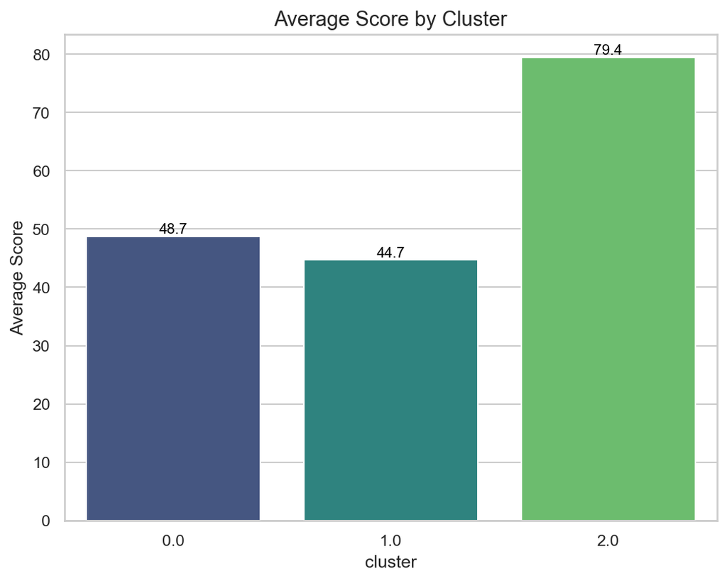

```python
import seaborn as sns

plt.figure(figsize=(8,6), dpi=150)
ax = sns.barplot(
    x=cluster_summary.index,
    y=cluster_summary["score"],
    palette="viridis"
)
plt.title("Average Score by Cluster", fontsize=14)
plt.ylabel("Average Score")

# Add labels on top of bars
for p in ax.patches:
    ax.annotate(
        f"{p.get_height():.1f}",
        (p.get_x() + p.get_width() / 2., p.get_height()),
        ha='center', va='bottom', fontsize=10, color='black'
    )

plt.show()
```

This confirms that the clustering effectively separates institutions into performance tiers.

### Distribution of Universities per Cluster

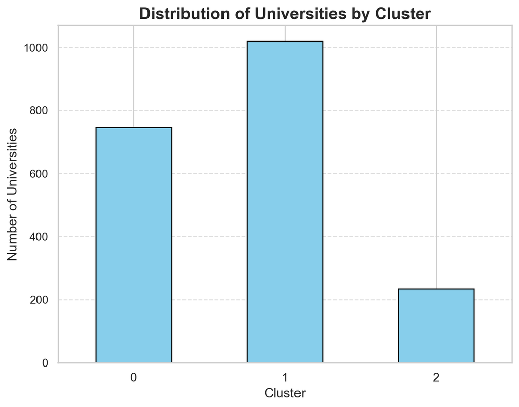

```python
# --- Distribution of Universities per Cluster ---
plt.figure(figsize=(8,6), dpi=200)

cwur_clustered["cluster"].value_counts().sort_index().plot(
    kind="bar",
    color="skyblue",
    edgecolor="black"
)

plt.xlabel("Cluster", fontsize=13)
plt.ylabel("Number of Universities", fontsize=13)
plt.title("Distribution of Universities by Cluster", fontsize=16, weight="bold")
plt.xticks(rotation=0, fontsize=12)
plt.yticks(fontsize=11)
plt.grid(axis="y", linestyle="--", alpha=0.6)

plt.show()
```

### Cluster Interpretation

This categorization provides a clear segmentation of global university performance levels and can be used for deeper comparative analysis.

## Cluster Distribution by Country

```python
# Cluster distribution by country (top 10 countries)
country_clusters = (
    cwur_clustered.groupby(["country", "cluster"])
    .size()
    .reset_index(name="count")
    .sort_values("count", ascending=False)
)

country_clusters.head(10)
```

|  | country | cluster | count |
| --- | --- | --- | --- |
| 107 | USA | 0 | 189 |
| 108 | USA | 1 | 149 |
| 19 | China | 1 | 123 |
| 109 | USA | 2 | 120 |
| 60 | Japan | 1 | 97 |
| 37 | Germany | 0 | 69 |
| 112 | United Kingdom | 0 | 58 |
| 35 | France | 1 | 55 |
| 95 | Spain | 1 | 52 |
| 113 | United Kingdom | 1 | 50 |

## Count universities per cluster

```python
cluster_counts = cwur_clustered["cluster"].value_counts().sort_index()
cluster_counts
```

```
cluster
0     746
1    1019
2     235
Name: count, dtype: int64
```

## Cluster Sizes

The distribution of universities across clusters shows how many institutions belong to each performance tier.  
This gives insights into whether elite institutions are concentrated in a small group, or spread more widely.

```python
cluster_stats = cwur_clustered.groupby("cluster")[["score"]].mean()
display(cluster_stats)
```

| cluster | score |
| --- | --- |
| 0 | 46.716515 |
| 1 | 44.518999 |
| 2 | 59.233532 |

# 7.Next Steps

The clustering analysis highlights performance tiers across global universities.

Future research could include hierarchical clustering for comparison, analyzing changes in clusters over time, or integrating additional features (e.g., funding, international collaborations). This would provide deeper insights into global university performance patterns.

For future analysis:

- Compare clusters across regions (e.g., Europe vs. Asia) to identify regional strengths.
- Investigate additional variables such as funding levels, student demographics, or international collaborations to refine clusters.
- Use clustering to track how universities move between groups over time.
- Apply alternative clustering methods (e.g., hierarchical clustering or DBSCAN) to validate the robustness of the results.